# MPM Group Project - AirBnb Price Prediction

Giedo, Micha, Azher, Christoph

4/25/2021

# Description of the Project

In this report, our group analyses the influence of different predictors on the listing price of AirBnb offerings in different cites in the United States.

The final model should provide a way to estimate the correct price for any new or existing object listed on AirBnB in order to ensure high booking rates. Also, it ensures users of this model to not underprice their object and lose out on improved margins. Please keep in mind, this model does not take into consideration the exact location or ‘cleanness’ of an object due to a lack of data. However, both of these predictors would have a high influence. Meaning, you apartment most likely still needs to be clean to result in a high booking rate.

# Data Preparation

As a first step, we load the data from our source .csv file and set all categorical values to be considered as factors. We also load the packages required to execute all our functions and calculations.

# Data Understanding / Data Analysis

Now we will take a deeper look at our data, the response variable log_price and all the available predictors.

Lets look at all the predictors of our data set.

```r
colnames(df.airbnb)
```

```
##  [1] "id"                     "log_price"              "property_type"
##  [4] "room_type"              "accommodates"           "bathrooms"
##  [7] "bed_type"               "cancellation_policy"    "cleaning_fee"
## [10] "city"                   "host_has_profile_pic"   "host_identity_verified"
## [13] "instant_bookable"       "number_of_reviews"      "review_scores_rating"
## [16] "bedrooms"               "beds"                   "amenities_Gym"
## [19] "amenities_WiFi"         "amenities_Pets"         "amenities_Breakfast"
```

```r
head(df.airbnb)
```

```
##         id log_price property_type room_type accommodates bathrooms bed_type
## 1  6901257  5.010635             0         0            3         1        4
## 2  6304928  5.129899             0         0            7         1        4
## 3  7919400  4.976734             0         0            5         1        4
## 4 13418779  6.620073            17         0            4         1        4
## 5  3808709  4.744932             0         0            2         1        4
## 6 12422935  4.442651             0         1            2         1        4
##   cancellation_policy cleaning_fee city host_has_profile_pic
## 1                   2            1    4                    1
## 2                   2            1    4                    1
## 3                   1            1    4                    1
## 4                   0            1    5                    1
## 5                   1            1    2                    1
## 6                   2            1    5                    1
##   host_identity_verified instant_bookable number_of_reviews
```

[output cut: 20 more lines]

```r
summary(df.airbnb)
```

```
##        id             log_price     property_type   room_type  accommodates
##  Min.   :     344   Min.   :2.303   0      :48609   0:41017   Min.   : 1.00
##  1st Qu.: 6255815   1st Qu.:4.317   17     :16424   1:30317   1st Qu.: 2.00
##  Median :12252055   Median :4.718   11     : 2649   2: 2136   Median : 2.00
##  Mean   :11262636   Mean   :4.783   28     : 1683             Mean   : 3.16
##  3rd Qu.:16396710   3rd Qu.:5.220   22     : 1236             3rd Qu.: 4.00
##  Max.   :21230903   Max.   :7.600   23     :  600             Max.   :16.00
##                                     (Other): 2269
##    bathrooms     bed_type  cancellation_policy cleaning_fee city
##  Min.   :0.000   0:  468   0:22338             0:19474      0: 3457
##  1st Qu.:1.000   1:  265   1:18916             1:53996      1: 3714
##  Median :1.000   2:  742   2:32092                          2: 5660
##  Mean   :1.194   3:  577   3:  107                          3:22268
##  3rd Qu.:1.000   4:71418   4:   17                          4:31975
##  Max.   :8.000                                              5: 6396
##
##  host_has_profile_pic host_identity_verified instant_bookable number_of_reviews
##  0:  224              0:24006                0:54150          Min.   :  0.00
##  1:73246              1:49464                1:19320          1st Qu.:  1.00
##                                                               Median :  6.00
##                                                               Mean   : 20.88
##                                                               3rd Qu.: 23.00
##                                                               Max.   :605.00
##
##  review_scores_rating    bedrooms           beds        amenities_Gym
##  Min.   : 20.00       Min.   : 0.000   Min.   : 0.000   0:66038
##  1st Qu.: 93.00       1st Qu.: 1.000   1st Qu.: 1.000   1: 7432
##  Median : 94.00       Median : 1.000   Median : 1.000
##  Mean   : 94.06       Mean   : 1.267   Mean   : 1.713
##  3rd Qu.: 99.00       3rd Qu.: 1.000   3rd Qu.: 2.000
##  Max.   :100.00       Max.   :10.000   Max.   :18.000
##
##  amenities_WiFi amenities_Pets amenities_Breakfast
##  0: 2778        0:63352        0:65222
##  1:70692        1:10118        1: 8248
##
##
##
##
##
```

The summary() command provides a first statistical overview of the data.

```r
str(df.airbnb)
```

```
## 'data.frame':    73470 obs. of  21 variables:
##  $ id                    : int  6901257 6304928 7919400 13418779 3808709 12422935 11825529 13971273 180792 5385260 ...
##  $ log_price             : num  5.01 5.13 4.98 6.62 4.74 ...
##  $ property_type         : Factor w/ 19 levels "0","1","2","3",..: 1 1 1 13 1 1 1 8 13 13 ...
##  $ room_type             : Factor w/ 3 levels "0","1","2": 1 1 1 1 1 2 1 1 2 2 ...
##  $ accommodates          : int  3 7 5 4 2 2 3 2 2 2 ...
##  $ bathrooms             : int  1 1 1 1 1 1 1 1 1 1 ...
##  $ bed_type              : Factor w/ 5 levels "0","1","2","3",..: 5 5 5 5 5 5 5 5 5 5 ...
##  $ cancellation_policy   : Factor w/ 5 levels "0","1","2","3",..: 3 3 2 1 2 3 2 2 2 2 ...
##  $ cleaning_fee          : Factor w/ 2 levels "0","1": 2 2 2 2 2 2 2 2 2 2 ...
##  $ city                  : Factor w/ 6 levels "0","1","2","3",..: 5 5 5 6 3 6 4 4 6 4 ...
##  $ host_has_profile_pic  : Factor w/ 2 levels "0","1": 2 2 2 2 2 2 2 2 2 2 ...
##  $ host_identity_verified: Factor w/ 2 levels "0","1": 2 1 2 2 2 2 1 2 1 1 ...
##  $ instant_bookable      : Factor w/ 2 levels "0","1": 1 2 2 1 2 2 2 1 1 2 ...
##  $ number_of_reviews     : int  2 6 10 0 4 3 15 9 159 2 ...
##  $ review_scores_rating  : int  100 93 92 94 40 100 97 93 99 90 ...
##  $ bedrooms              : int  1 3 1 2 0 1 1 1 1 1 ...
##  $ beds                  : int  1 3 3 2 1 1 1 1 1 1 ...
##  $ amenities_Gym         : Factor w/ 2 levels "0","1": 1 1 1 1 1 1 2 1 1 1 ...
##  $ amenities_WiFi        : Factor w/ 2 levels "0","1": 2 2 2 2 2 2 2 2 2 2 ...
##  $ amenities_Pets        : Factor w/ 2 levels "0","1": 1 1 1 1 1 1 1 1 1 1 ...
##  $ amenities_Breakfast   : Factor w/ 2 levels "0","1": 1 1 2 1 1 1 1 1 1 1 ...
```

# Defining the Measure of Fit and Cross Validation Approach

In order to have a consistent evaluation of our models and cross validate all our models in the same way, the measure of fit as well as the cross validation approach will be explained in this section.

For the cross validation, we will use a 10-fold approach. Meaning, we will split our data into 10 groups of equal size and randomly assigned observations. When testing, every model will run at least once with every combination of test and train data combination.

## Applying the Possion Distribution

As our response variable is a continuous variable, we cannot apply the Poisson distribution to it. To show how this would work, we are going to consider another variable as a response variable.

For this example, we choose the variable ‘number_of_reviews’ where we want to determine if some predictors influence number of reviews an object receives.

Let first do some graphical analysis on the response variable an some predictors.

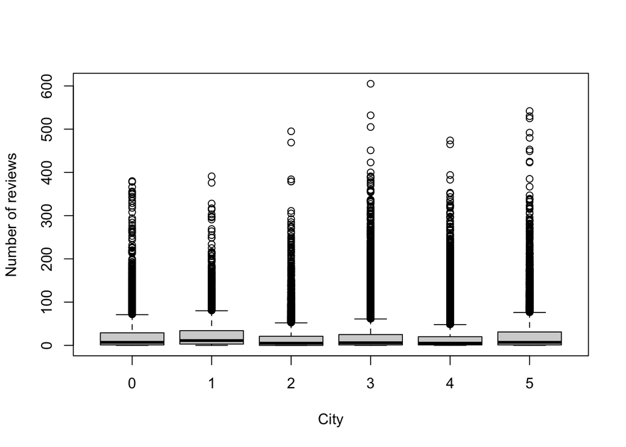

```r
boxplot(number_of_reviews ~ city,
        ylab = "Number of reviews",
        xlab = "City",
        data = df.airbnb)
```

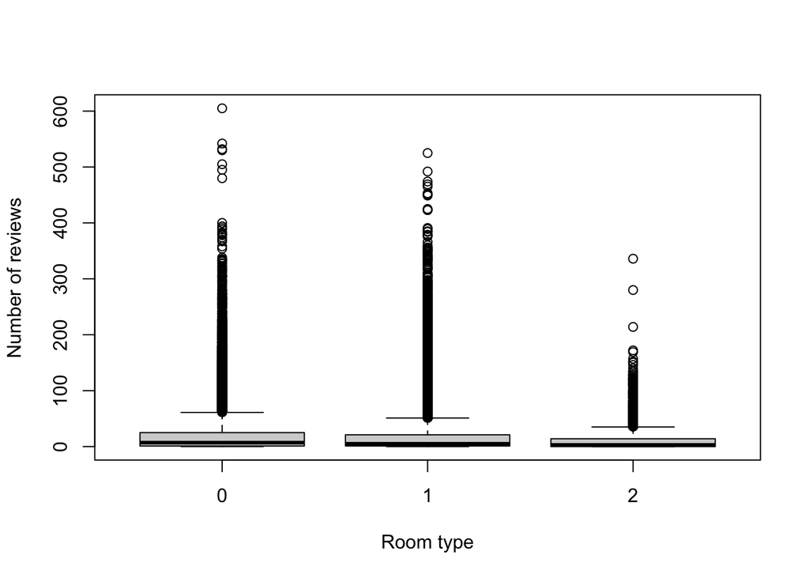

```r
boxplot(number_of_reviews ~ room_type,
        ylab = "Number of reviews",
        xlab = "Room type",
        data = df.airbnb)
```

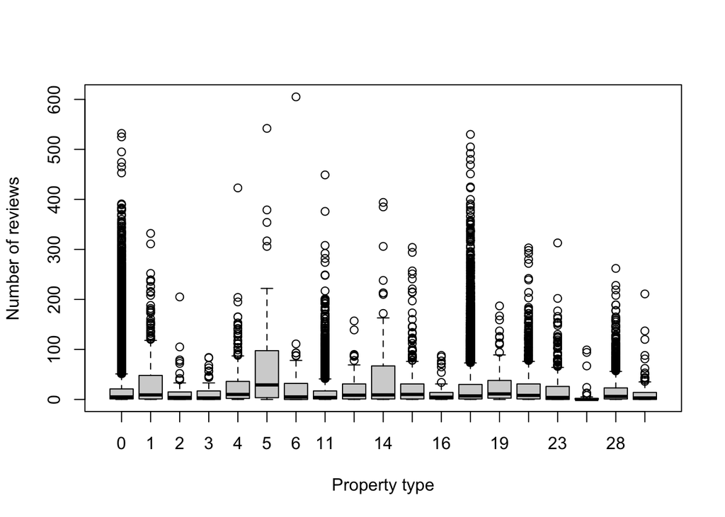

```r
boxplot(number_of_reviews ~ property_type,
        ylab = "Number of reviews",
        xlab = "Property type",
        data = df.airbnb)
```

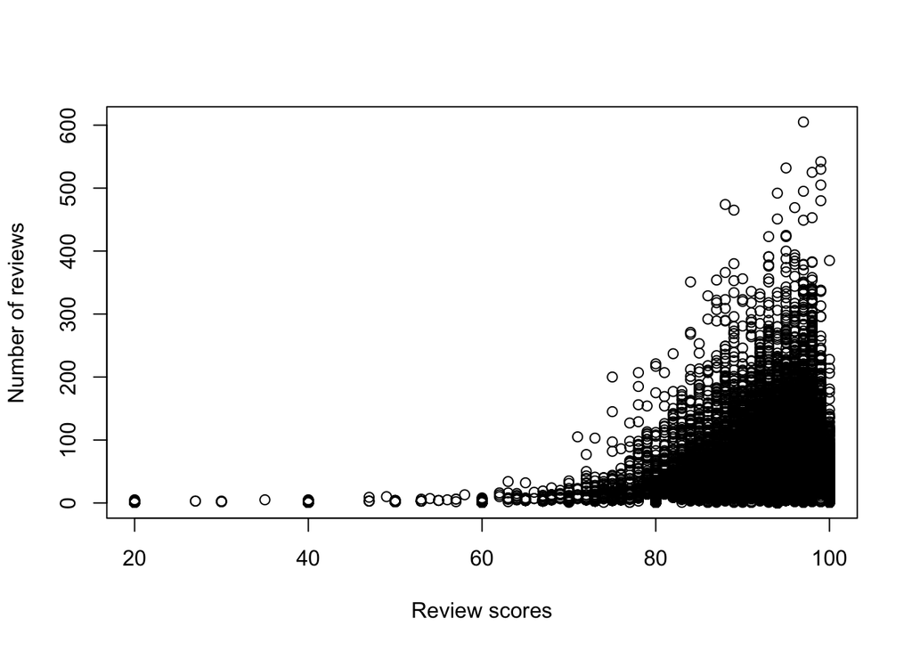

```r
plot(number_of_reviews ~ review_scores_rating,
        ylab = "Number of reviews",
        xlab = "Review scores",
        data = df.airbnb)
```

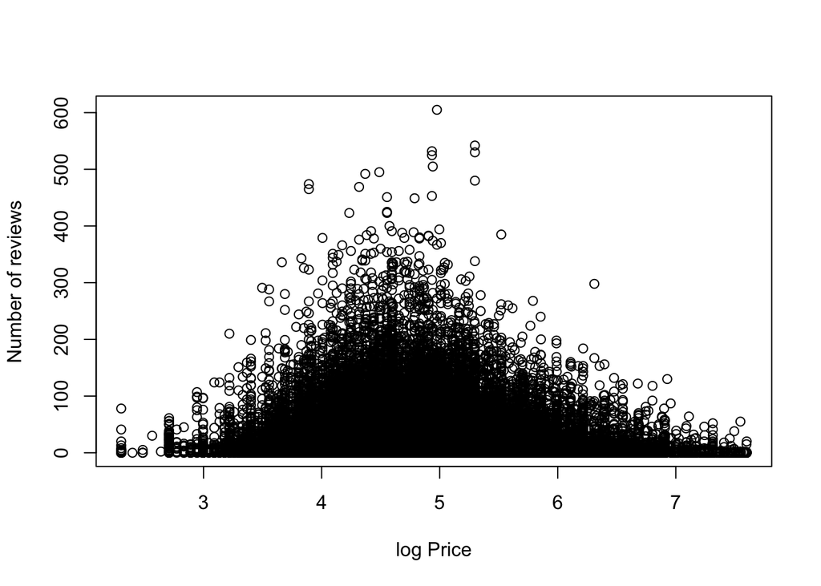

```r
plot(number_of_reviews ~ log_price,
        ylab = "Number of reviews",
        xlab = "log Price",
        data = df.airbnb)
```

Lets first create a simple model and a complex model. An see if the predictors indicate evidence for an influence.

```r
glm.df.airbnb.50 <- glm(number_of_reviews ~ city + room_type +
                          review_scores_rating + log_price + property_type,
                        family = "poisson",
                        data = df.airbnb)
summary(glm.df.airbnb.50)
```

```
##
## Call:
## glm(formula = number_of_reviews ~ city + room_type + review_scores_rating +
##     log_price + property_type, family = "poisson", data = df.airbnb)
##
## Deviance Residuals:
##     Min       1Q   Median       3Q      Max
## -13.150   -5.597   -3.804    0.541   52.605
##
## Coefficients:
##                        Estimate Std. Error  z value Pr(>|z|)
## (Intercept)           4.3414882  0.0139582  311.035  < 2e-16 ***
## city1                -0.0398909  0.0046623   -8.556  < 2e-16 ***
## city2                -0.3045899  0.0045137  -67.481  < 2e-16 ***
## city3                -0.3116036  0.0037288  -83.568  < 2e-16 ***
## city4                -0.3518273  0.0036334  -96.831  < 2e-16 ***
## city5                 0.1354587  0.0041312   32.789  < 2e-16 ***
## room_type1           -0.2890526  0.0021585 -133.916  < 2e-16 ***
## room_type2           -0.8437048  0.0065127 -129.548  < 2e-16 ***
## review_scores_rating  0.0027494  0.0001227   22.401  < 2e-16 ***
## log_price            -0.2622712  0.0015546 -168.704  < 2e-16 ***
## property_type1        0.6381300  0.0082205   77.627  < 2e-16 ***
## property_type2       -0.2883463  0.0313127   -9.209  < 2e-16 ***
## property_type3       -0.3727183  0.0321550  -11.591  < 2e-16 ***
## property_type4        0.2915008  0.0101749   28.649  < 2e-16 ***
## property_type5        1.2667866  0.0136773   92.620  < 2e-16 ***
## property_type6        0.1657362  0.0205815    8.053 8.10e-16 ***
## property_type11      -0.2252135  0.0049342  -45.643  < 2e-16 ***
## property_type12       0.1434833  0.0196524    7.301 2.86e-13 ***
## property_type14       0.7058222  0.0131664   53.608  < 2e-16 ***
## property_type15       0.1875809  0.0090640   20.695  < 2e-16 ***
## property_type16      -0.1591918  0.0324103   -4.912 9.03e-07 ***
## property_type17       0.2680421  0.0020618  130.005  < 2e-16 ***
## property_type19       0.1430728  0.0209105    6.842 7.80e-12 ***
## property_type22       0.2704404  0.0059154   45.718  < 2e-16 ***
## property_type23       0.0304182  0.0092534    3.287  0.00101 **
## property_type26      -1.3757815  0.0517749  -26.572  < 2e-16 ***
## property_type28      -0.0043051  0.0058738   -0.733  0.46360
## property_type32      -0.3406208  0.0217566  -15.656  < 2e-16 ***
## ---
## Signif. codes:  0 '***' 0.001 '**' 0.01 '*' 0.05 '.' 0.1 ' ' 1
##
## (Dispersion parameter for poisson family taken to be 1)
##
##     Null deviance: 3096713  on 73469  degrees of freedom
## Residual deviance: 2987584  on 73442  degrees of freedom
## AIC: 3230657
##
## Number of Fisher Scoring iterations: 6
```

We see that almost all predictors and factor levels seem to have some sort of influence.

Lets create a more complex model and see the results.

```r
glm.df.airbnb.51 <-glm(number_of_reviews ~ log_price + property_type + room_type +
                         accommodates + bathrooms + bed_type + cancellation_policy +
                         cleaning_fee + city + host_has_profile_pic +
                         host_identity_verified + instant_bookable +
                         review_scores_rating + bedrooms + beds + amenities_Breakfast +
                         amenities_Gym + amenities_Pets + amenities_WiFi,
                        family = "quasipoisson",
                        data = df.airbnb)
summary(glm.df.airbnb.51)
```

```
##
## Call:
## glm(formula = number_of_reviews ~ log_price + property_type +
##     room_type + accommodates + bathrooms + bed_type + cancellation_policy +
##     cleaning_fee + city + host_has_profile_pic + host_identity_verified +
##     instant_bookable + review_scores_rating + bedrooms + beds +
##     amenities_Breakfast + amenities_Gym + amenities_Pets + amenities_WiFi,
##     family = "quasipoisson", data = df.airbnb)
##
## Deviance Residuals:
##     Min       1Q   Median       3Q      Max
## -17.301   -4.764   -2.912    0.449   49.839
##
## Coefficients:
##                           Estimate Std. Error t value Pr(>|t|)
## (Intercept)              1.1148502  0.2426876   4.594 4.36e-06 ***
## log_price               -0.1928356  0.0139741 -13.800  < 2e-16 ***
## property_type1           0.7105151  0.0625401  11.361  < 2e-16 ***
## property_type2           0.0763579  0.2336416   0.327 0.743808
## property_type3          -0.1299181  0.2399677  -0.541 0.588235
## property_type4           0.1724469  0.0759249   2.271 0.023133 *
## property_type5           1.2636854  0.1020401  12.384  < 2e-16 ***
## property_type6           0.3512676  0.1538194   2.284 0.022396 *
## property_type11         -0.2154747  0.0368406  -5.849 4.97e-09 ***
## property_type12         -0.0463802  0.1494252  -0.310 0.756265
## property_type14          0.5751335  0.0981427   5.860 4.64e-09 ***
## property_type15          0.0551062  0.0676922   0.814 0.415607
## property_type16         -0.4574452  0.2449554  -1.867 0.061841 .
## property_type17          0.2206361  0.0161065  13.699  < 2e-16 ***
## property_type19          0.0048548  0.1558009   0.031 0.975142
## property_type22          0.1282283  0.0443404   2.892 0.003830 **
## property_type23         -0.0357981  0.0693546  -0.516 0.605744
## property_type26         -1.2508359  0.3858419  -3.242 0.001188 **
## property_type28         -0.0968076  0.0440097  -2.200 0.027832 *
## property_type32         -0.4185557  0.1622129  -2.580 0.009874 **
## room_type1              -0.0016870  0.0170689  -0.099 0.921269
## room_type2              -0.4430071  0.0509518  -8.695  < 2e-16 ***
## accommodates             0.0715001  0.0051255  13.950  < 2e-16 ***
## bathrooms               -0.1484697  0.0159140  -9.329  < 2e-16 ***
## bed_type1                0.0733821  0.1591725   0.461 0.644784
```

[output cut: 18 more lines]

```
## beds                     0.0563260  0.0079321   7.101 1.25e-12 ***
## amenities_Breakfast1    -0.0726376  0.0199463  -3.642 0.000271 ***
## amenities_Gym1          -0.3628328  0.0244234 -14.856  < 2e-16 ***
## amenities_Pets1         -0.0036701  0.0177002  -0.207 0.835737
## amenities_WiFi1          0.9770272  0.0606549  16.108  < 2e-16 ***
## ---
## Signif. codes:  0 '***' 0.001 '**' 0.01 '*' 0.05 '.' 0.1 ' ' 1
##
## (Dispersion parameter for quasipoisson family taken to be 55.46548)
##
##     Null deviance: 3096713  on 73469  degrees of freedom
## Residual deviance: 2520001  on 73422  degrees of freedom
## AIC: NA
##
## Number of Fisher Scoring iterations: 6
```

Again, most of the predictors have an influence, let’s ensure this even further.

```r
drop1(glm.df.airbnb.51, test = "F")
```

```
## Single term deletions
##
## Model:
## number_of_reviews ~ log_price + property_type + room_type + accommodates +
##     bathrooms + bed_type + cancellation_policy + cleaning_fee +
##     city + host_has_profile_pic + host_identity_verified + instant_bookable +
##     review_scores_rating + bedrooms + beds + amenities_Breakfast +
##     amenities_Gym + amenities_Pets + amenities_WiFi
##                        Df Deviance   F value    Pr(>F)
## <none>                     2520001
## log_price               1  2530702  311.7882 < 2.2e-16 ***
## property_type          18  2549115   47.1254 < 2.2e-16 ***
## room_type               2  2525144   74.9175 < 2.2e-16 ***
## accommodates            1  2529989  291.0182 < 2.2e-16 ***
## bathrooms               1  2525052  147.1542 < 2.2e-16 ***
## bed_type                4  2522021   14.7107 5.133e-12 ***
## cancellation_policy     4  2686790 1214.8776 < 2.2e-16 ***
## cleaning_fee            1  2521888   54.9695 1.237e-13 ***
## city                    5  2553228  193.6154 < 2.2e-16 ***
## host_has_profile_pic    1  2520298    8.6495  0.003272 **
## host_identity_verified  1  2603033 2419.2055 < 2.2e-16 ***
## instant_bookable        1  2547806  810.1096 < 2.2e-16 ***
## review_scores_rating    1  2520673   19.5704 9.710e-06 ***
## bedrooms                1  2543692  690.2617 < 2.2e-16 ***
## beds                    1  2522721   79.2482 < 2.2e-16 ***
## amenities_Breakfast     1  2520750   21.8123 3.012e-06 ***
## amenities_Gym           1  2533434  391.3757 < 2.2e-16 ***
## amenities_Pets          1  2520003    0.0695  0.792014
## amenities_WiFi          1  2539981  582.1434 < 2.2e-16 ***
## ---
## Signif. codes:  0 '***' 0.001 '**' 0.01 '*' 0.05 '.' 0.1 ' ' 1
```

Apart from the preditcor “amenities_Pets” all predictors seem to have an influence, hence our final model will use all predictors except the one mentioned before.

```r
glm.df.airbnb.52 <- update(glm.df.airbnb.51, . ~ . - amenities_Pets)
```

Additionally, we will create a GAM model to account for non-linerar relationships of the two continuous predictors “log_price” and “review_scores_rating”.

```r
gam.df.airbnb.53 <- gam(number_of_reviews ~ s(log_price) + property_type + room_type +
                          accommodates + bathrooms + bed_type + cancellation_policy +
                          cleaning_fee + city + host_has_profile_pic +
                          host_identity_verified + instant_bookable +
                          s(review_scores_rating) + bedrooms + beds +
                          amenities_Breakfast + amenities_Gym + amenities_WiFi,
                        family = "quasipoisson",
                        data = df.airbnb)
```

To check which model fits better, we will run a 10-fold cross validation check.

```r
set.seed(544)
r.squared.simple <- c()
r.squared.complex <- c()
# shuffle data
df.airbnb <- df.airbnb[sample(nrow(df.airbnb)),]
folds <- cut(seq(1,nrow(df.airbnb)), breaks = 10, labels = FALSE)
for(i in 1:10){
  testIndexes <- which(folds==i, arr.ind = TRUE)
  df.airbnb.test <- df.airbnb[testIndexes, ]
  df.airbnb.train <- df.airbnb[-testIndexes, ]
  ## insert your models - simple
  # fit the model with test data
  model.1.train <- glm(formula = formula(glm.df.airbnb.52),
                       data = df.airbnb.train)
  # predict the model
  predicted.model.1.test <- predict(model.1.train,
                                    newdata = df.airbnb.test)
  # compute R^2
  r.squared.simple[i] <- cor(predicted.model.1.test,
                             df.airbnb.test$number_of_reviews)^2
  ## insert you model - complex
  # fit the model with test data
  model.2.train <- gam(formula = formula(gam.df.airbnb.53),
                       data = df.airbnb.train)
  # predict the model
  predicted.model.2.test <- predict(model.2.train,
                                    newdata = df.airbnb.test)
  # compute R^2
  r.squared.complex[i] <- cor(predicted.model.2.test,
                           df.airbnb.test$number_of_reviews)^2
}
```

```r
print(mean(r.squared.simple)*100)
```

```
## [1] 10.22684
```

```r
print(mean(r.squared.complex)*100)
```

```
## [1] 12.50048
```

From the results we can see, the GAM model fits better and should therefore be considered. However, the result is not great and more predictors should be evaluated to come up with a better model.